# Advanced Econometrics

Parviz Hajizada

17 may 2019

# Introduction

### Load necessary packages

```r
library(ggplot2)
library(dplyr)
library(RColorBrewer)
library(corrplot)
library(lfe)
library(FENmlm)
library(MLmetrics)
library(reshape)
library(stargazer)
library(moments)
library(purrr)
```

### Import data

```r
market <- read.csv2("market.csv")
dim(market)
```

```
## [1] 111047     20
```

# Exploratory Data Analysis

### Descriptive statistics

```r
sapply(market, class)
```

```
##           iso3_o             year           iso3_d           origin
##         "factor"        "integer"         "factor"         "factor"
##      destination       passengers      revenue_usd         capacity
##         "factor"        "integer"        "integer"        "integer"
##        frequency         distance         domestic intercontinental
##        "integer"        "integer"        "integer"        "integer"
##          dist200         GDPCAP_o            POP_o         GDPCAP_d
##        "integer"        "integer"        "integer"        "integer"
##            POP_d              rta               cu              fta
##        "integer"        "integer"        "integer"        "integer"
```

```r
head(market)
```

```
##   iso3_o year iso3_d origin   destination passengers revenue_usd capacity
## 1    ABW 2002    USA  Aruba  Philadelphia      35964     7175852    50018
## 2    ABW 2002    USA  Aruba       Chicago      14837     3328898    20268
## 3    ABW 2002    VEN  Aruba     Maracaibo      34956     3341887    32506
## 4    ABW 2002    DOM  Aruba Santo Domingo      14729     3988282    20695
## 5    ABW 2002    USA  Aruba      New York     100686    26007790   141776
## 6    ABW 2002    USA  Aruba       Chicago      14837     3328898    20268
##   frequency distance domestic intercontinental dist200 GDPCAP_o POP_o
## 1       365     3094        0                1       0    20436 94992
## 2       114     3691        0                1       0    20436 94992
## 3       560      285        0                0       0    20436 94992
## 4       191      674        0                1       0    20436 94992
## 5       735     3150        0                1       0    20436 94992
## 6       114     3706        0                1       0    20436 94992
##   GDPCAP_d     POP_d rta cu fta
## 1    38166 287625193   0  0   0
## 2    38166 287625193   0  0   0
## 3     3655  25408700   0  0   0
## 4     3098   8832285   0  0   0
## 5    38166 287625193   0  0   0
## 6    38166 287625193   0  0   0
```

```r
any(is.na(market))
```

```
## [1] FALSE
```

### Change class of variables

```r
# Convert into factors (year converted into factor intentionally)
facts <- c("year", "origin", "destination", "iso3_o", "iso3_d", "domestic",
           "intercontinental", "dist200", "rta", "cu", "fta")
market[,facts] <- lapply(market[,facts], as.factor)

# COnvert into integers
nums <- c("passengers", "revenue_usd", "capacity", "frequency",
          "distance", "POP_o", "POP_d", "GDPCAP_o", "GDPCAP_d")
market[,nums] <- lapply(market[,nums], as.integer)
```

#### Number of unique levels of categorical variables

```r
market %>%
  select_if(is.factor) %>%
  map_dfr(function(x) length(unique(x)))
```

```
## # A tibble: 1 x 11
##   iso3_o  year iso3_d origin destination domestic intercontinental dist200
##    <int> <int>  <int>  <int>       <int>    <int>            <int>   <int>
## 1    159    16    161    970        1007        2                2       2
## # ... with 3 more variables: rta <int>, cu <int>, fta <int>
```

Variables origin and destination have both around 1000 levels. When the number of levels are so high, it is either impossible or even if it is possible then very time and memory consuming to run functions like lm, plm, glm. Instead functions from lfe and FENmlm packages are used in the project. lfe package for OLS with fixed effects, FENmlm package for PPML, NBPML, GAUSSIAN with fixed effects.

#### How total number of passengers changed over years

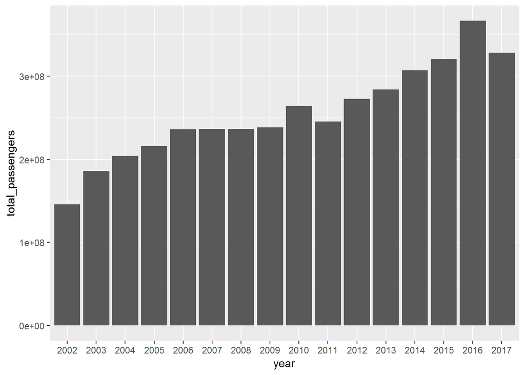

```r
market %>%
  group_by(year) %>%
  summarise(total_passengers = sum(passengers)) %>%
  ggplot(aes(x = year, y = total_passengers)) +
  geom_col()
```

It can be seen that number of passengers has an upward trend over the years.

#### How total revenue changed over years

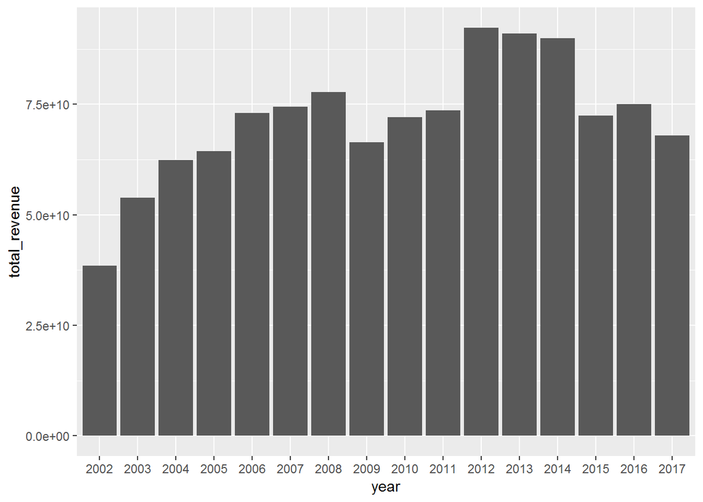

```r
market %>%
  group_by(year) %>%
  summarise(total_revenue = sum(as.numeric(revenue_usd))) %>%
  ggplot(aes(x = year, y = total_revenue)) +
  geom_col()
```

Revenue does not have such a clear trend. Revenues droped during 2009 relative to 2008 probably because of financial crisis and then rises to very high levels during 2012-2014 because of high oil prices and later it drops with falling oil prices. A better representation of revenue change can be shown by average fare which is computed as total_revenue / total_passengers.

#### How average fair changed over years

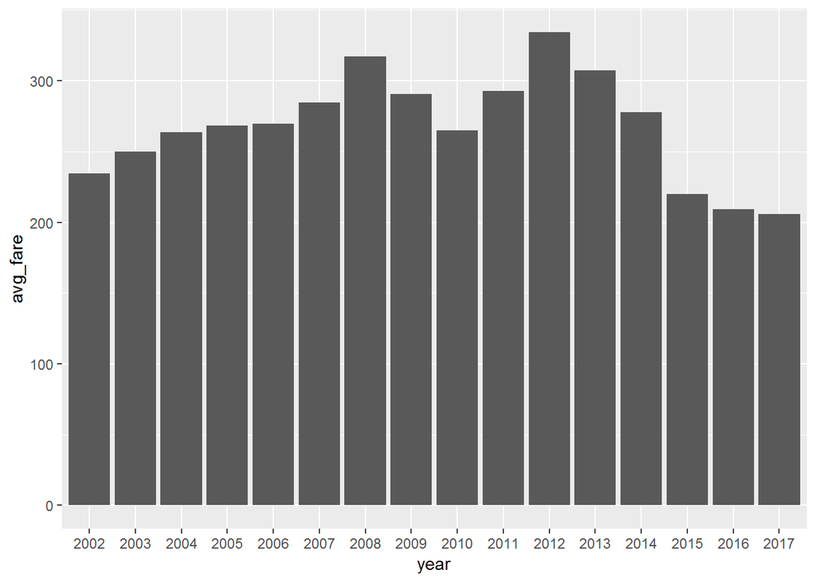

```r
market %>%
  group_by(year) %>%
  summarise(avg_fare = mean(revenue_usd/ passengers)) %>%
  ggplot(aes(x = year, y = avg_fare)) +
  geom_col()
```

We can see that during 2009-2010 and 2015-2017 periods avg_fare are pretty low because of financial crisis and oil price ‘crisis’ respectively.

#### How frequency of flights impact number of passengers

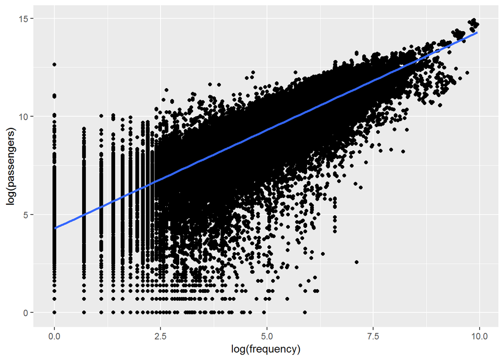

```r
market %>%
  ggplot(aes(x = log(frequency), y = log(passengers))) +
  geom_point() +
  geom_smooth(method = "lm")
```

Just as expected, rise in frequency of flights causes number of passengers to rise. It is done in log scale because the trend is not recognizable in original scale.

#### Relationship between distance and passengers

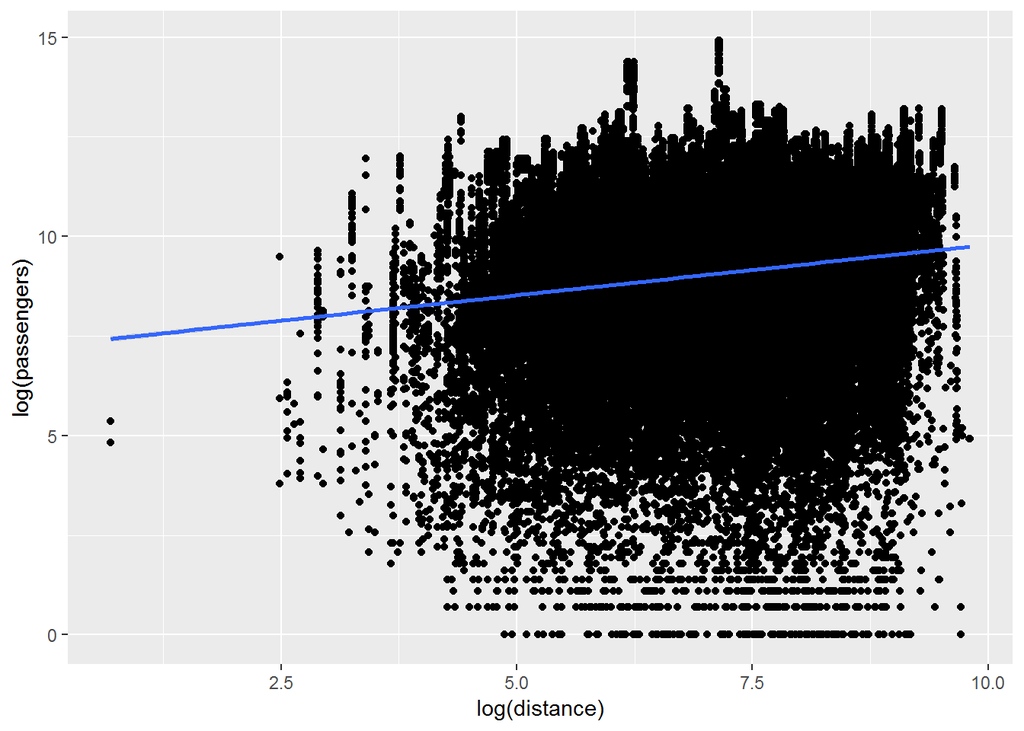

```r
market %>%
  ggplot(aes(x = log(distance), y = log(passengers))) +
  geom_point() +
  geom_smooth(method = "lm")
```

Graph indicates positive relationship between log of distance and log of passengers. It is against literature of gravity where the relationship found to be negative. I cannot explain this counterintuitive finding but I found it important to include here.

#### Impact of average fare per km on passengers

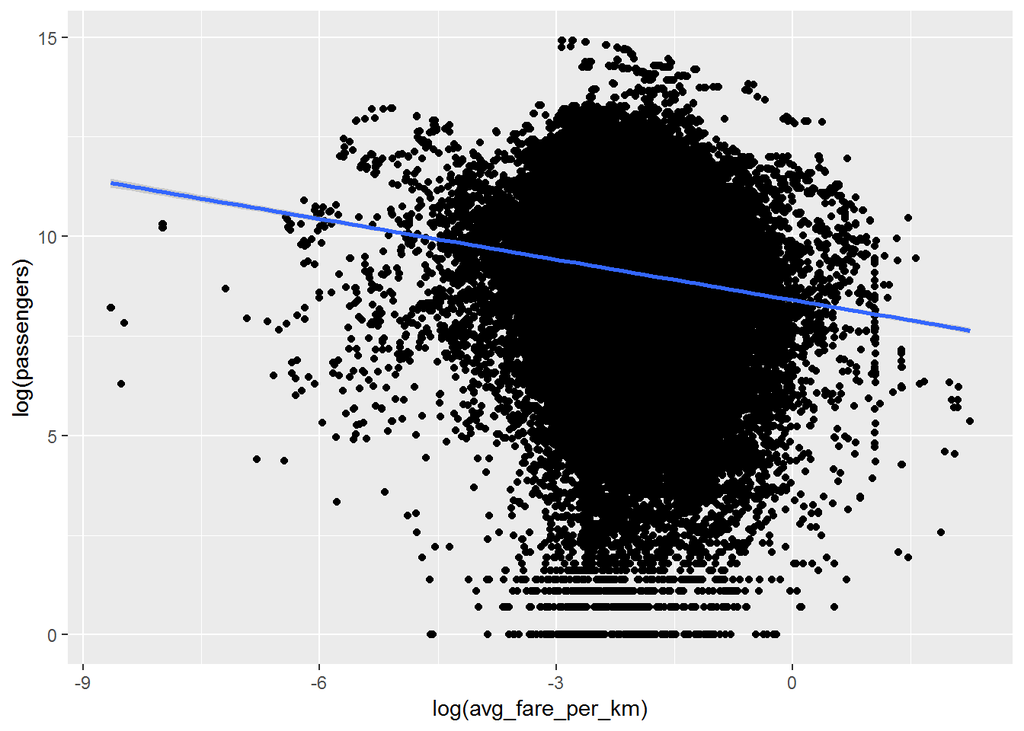

```r
market %>%
  mutate(avg_fare_per_km = (revenue_usd/ passengers) / distance) %>%
  ggplot(aes(x = log(avg_fare_per_km), y = log(passengers))) +
  geom_point() +
  geom_smooth(method = "lm")
```

Negative relationship as expected. As the average fare per km increases people are less likely to travel.

#### GDP of origin country against passengers

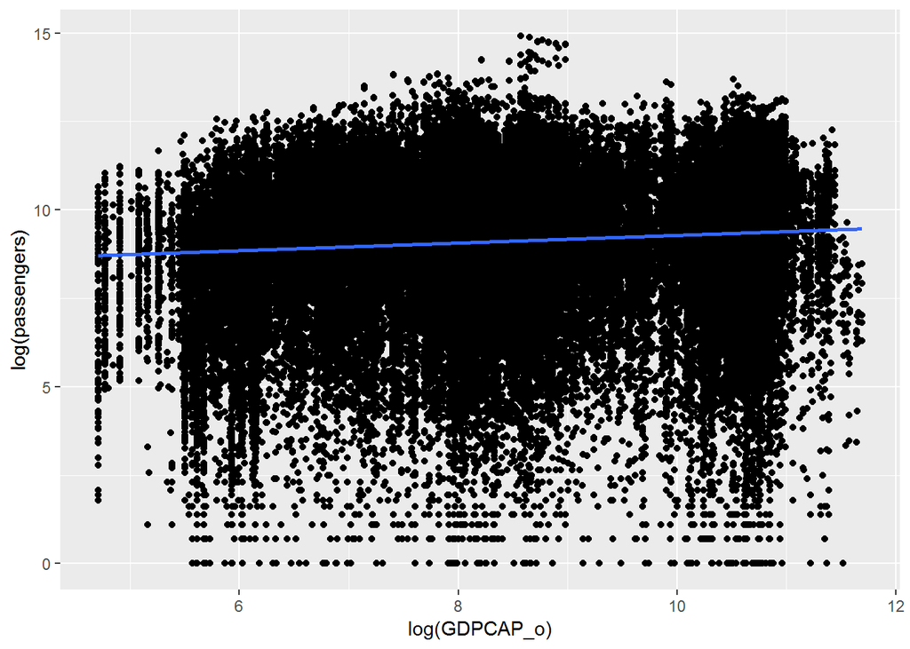

```r
market %>%
  ggplot(aes(x = log(GDPCAP_o), y = log(passengers))) +
  geom_point() +
  geom_smooth(method = "lm")
```

It can be seen that increasing GDP is linked with higher number of passengers which is quite intuitive. The richer the nation, the easier to afford to travel.

#### Average fare per km over time for short and long distance trips

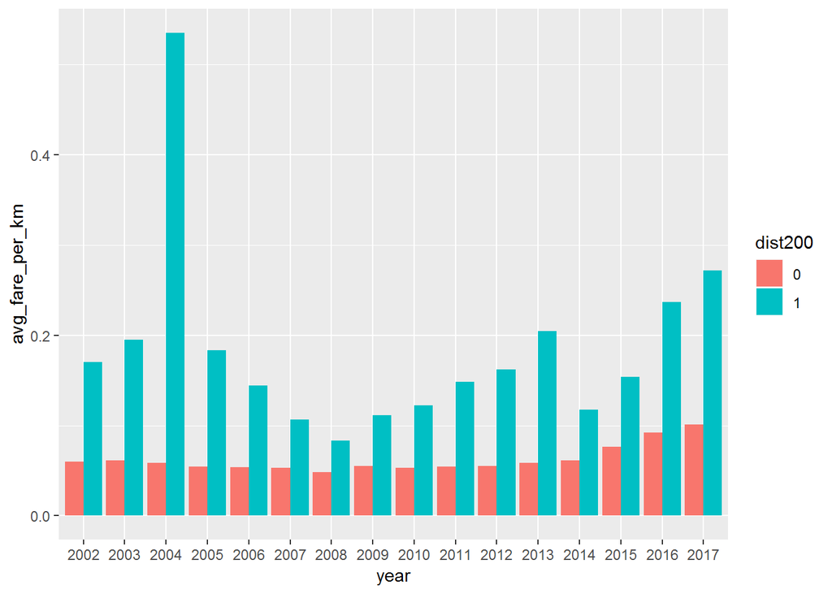

```r
market %>%
  group_by(year, dist200) %>%
  summarise(avg_fare_per_km = sum((passengers / revenue_usd) / distance)) %>%
  ggplot(aes(x = year, y = avg_fare_per_km, fill = dist200)) +
  geom_col(position = "dodge")
```

#### How number of passengers differs by year and whether the flight is domestic

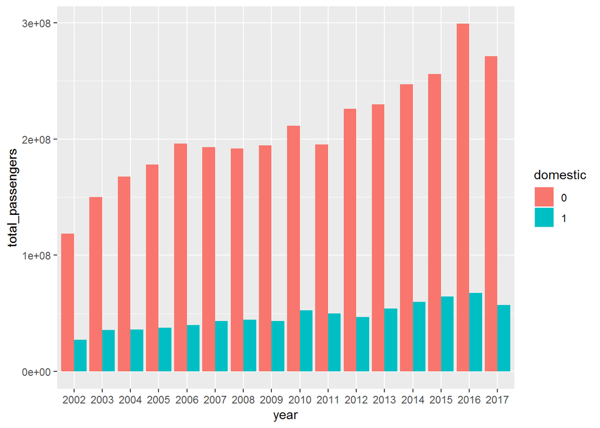

```r
market %>%
  group_by(year, domestic) %>%
  summarise(total_passengers = sum(passengers)) %>%
  ggplot(aes(x = year, y = total_passengers, fill = domestic)) +
  geom_col(position = "dodge")
```

Turns out most of the flights are not domestic and ratio of domestic to non domestic is pretty stable over time. domestic == 1 when the flight is domestic.

#### How number of passengers differs by year and whether the flight is intercontinental

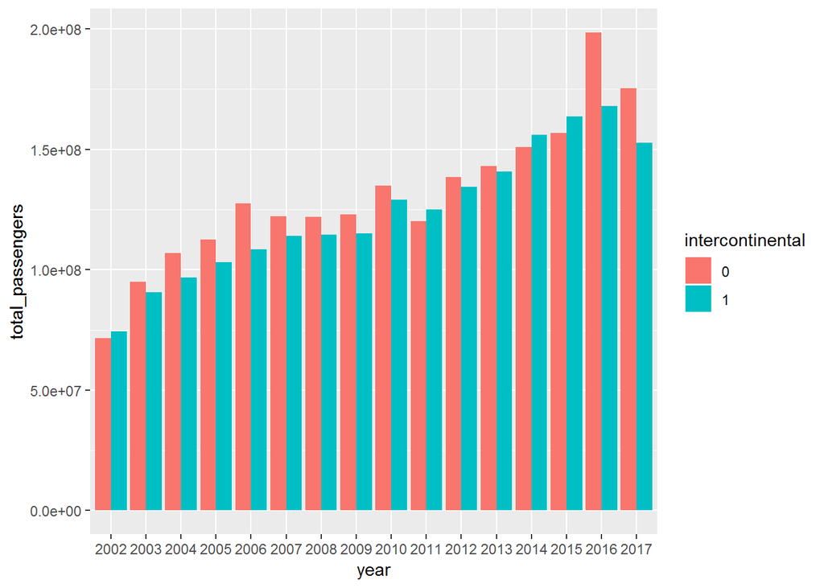

```r
market %>%
  group_by(year, intercontinental) %>%
  summarise(total_passengers = sum(passengers)) %>%
  ggplot(aes(x = year, y = total_passengers, fill = intercontinental)) +
  geom_col(position = "dodge")
```

Looks like number of intercontinental and non intercontinental flights are similar over year. There is only a little difference; a bit less intercontinental flights. intercontinental == 1 when the flight is intercontinental.

### Feature engineering

Let’s create variables that was found to be significant during EDA

```r
# Create average fare per km feature
market <- market %>%
  mutate(avg_fare_per_km = (revenue_usd/ passengers) / distance)

# Add the feature to numeric features list
nums <- c("passengers", "revenue_usd", "capacity", "frequency",
          "distance", "POP_o", "POP_d", "GDPCAP_o", "GDPCAP_d", "avg_fare_per_km")
```

### Correlations

```r
# Calculate pairwise correlation and sort it in ascending order
cor(market$passengers, market[nums], use="pairwise.complete.obs") %>%
  as.data.frame(row.names = 'Correlation') %>%
  sort() %>%
  t()
```

```
##                  Correlation
## avg_fare_per_km -0.048365814
## GDPCAP_o         0.008251727
## distance         0.038602679
## POP_o            0.053941725
## POP_d            0.064685568
## GDPCAP_d         0.074479866
## revenue_usd      0.658814498
## frequency        0.811519035
## capacity         0.969079869
## passengers       1.000000000
```

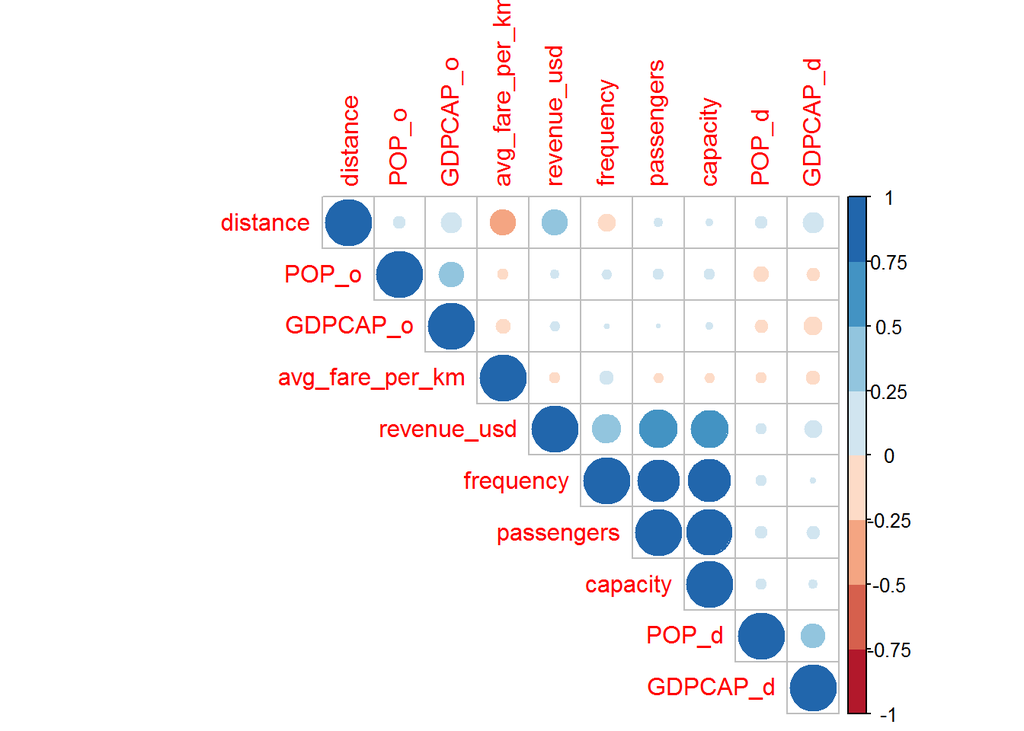

```r
# Correlation plot
corrplot(cor(market[nums]), type="upper", order="hclust",
         col=brewer.pal(n=8, name="RdBu"))
```

# Model estimation

#### OLS - Ordinary Least Squares

```r
OLS <- lm(data = market, log(passengers) ~
            # numerical variables
            log(avg_fare_per_km) + log(frequency) + log(GDPCAP_o) +
            log(GDPCAP_d) + log(POP_o) + log(POP_d) + log(distance) +
            # categorical variables
            rta + cu + domestic + intercontinental + dist200)
            # no fixed effects
```

#### FE - Ordinary Least Squares with Fixed Effects

```r
FE <- felm(data = market, log(passengers) ~
              # numerical variables
              log(avg_fare_per_km) + log(frequency) + log(GDPCAP_o) +
              log(GDPCAP_d) + log(POP_o) + log(POP_d) + log(distance) +
              # categorical variables
              rta + cu + domestic + intercontinental + dist200
             |
              # fixed effects
              year + origin + destination)
```

#### PPML - Poisson Pseudo Maximum Likelihood with Fixed Effects

```r
PPML <- femlm(passengers ~
                # numerical variables
                log(avg_fare_per_km) + log(frequency) + log(GDPCAP_o) +
                log(GDPCAP_d) + log(POP_o) + log(POP_d) + log(distance) +
                # categorical variables
                rta + cu + domestic + intercontinental + dist200
               |
                # fixed effects
                year + origin + destination,
                data = market,
                family = "poisson")
```

#### NBPML - Negative Binomial Pseudo Maximum Likelihood with Fixed Effects

```r
NBPML <- femlm(passengers ~
                 # numerical variables
                 log(avg_fare_per_km) + log(frequency) + log(GDPCAP_o) +
                 log(GDPCAP_d) + log(POP_o) + log(POP_d) + log(distance) +
                 # categorical variables
                 rta + cu + domestic + intercontinental + dist200
                |
                 # fixed effects
                 year + origin + destination,
                 data = market,
                 family = "negbin")
```

#### Gaussian - Gaussian with Fixed Effects

```r
GAUSSIAN <- femlm(passengers ~
                    # numerical variables
                    log(avg_fare_per_km) + log(frequency) + log(GDPCAP_o) +
                    log(GDPCAP_d) + log(POP_o) + log(POP_d) + log(distance) +
                    # categorical variables
                    rta + cu + domestic + intercontinental + dist200
                   |
                    # fixed effects
                    year + origin + destination,
                    data = market,
                    family = "gaussian")
```

# Comparison of PPML, NBPML and GAUSSIAN

```r
res2table(PPML, NBPML, GAUSSIAN,
          se = "twoway",
          subtitles = c("PPML", "NBPML", "GAUSSIAN"))
```

```
##                                    PPML              NBPML
## log(avg_fare_per_km)   0.0562* (0.0294)    0.0228 (0.0214)
## log(frequency)        0.9438*** (0.016) 0.8712*** (0.0201)
## log(GDPCAP_o)           0.0593 (0.0827)  0.1377** (0.0639)
## log(GDPCAP_d)        -0.1311** (0.0602)   -0.0863 (0.0557)
## log(POP_o)               0.0091 (0.101)  0.2362** (0.1138)
## log(POP_d)               0.0541 (0.072)   0.283** (0.1121)
## log(distance)        0.2164*** (0.0296) 0.1709*** (0.0241)
## rta1                 -0.0618** (0.0287)   -0.0347 (0.0336)
## cu1                     0.086* (0.0471) 0.1526*** (0.0551)
## domestic1            0.1438*** (0.0533)  0.328*** (0.0828)
## intercontinental1      -0.0456 (0.0642) -0.2627** (0.1093)
## dist2001              -0.0986* (0.0598)   0.0782* (0.0461)
## Overdispersion:                                     2.2772
## Fixed-Effects:       ------------------ ------------------
## year                                Yes                Yes
## origin                              Yes                Yes
## destination                         Yes                Yes
## ____________________ __________________ __________________
## Family:                         Poisson          Neg. Bin.
## Observations                    111,047            111,047
## Squared-Correlation               0.945              0.891
## Adj-pseudo R2                   0.94477            0.08869
## Log-Likelihood          -235,289,027.61      -1,136,143.05
## BIC                      470,601,325.50       2,295,567.99
##                                        GAUSSIAN
## log(avg_fare_per_km)    -3234.2405* (1858.0011)
## log(frequency)        20147.4152*** (1723.7005)
## log(GDPCAP_o)           7127.7792** (3082.2304)
## log(GDPCAP_d)          -3452.4225** (1385.8558)
## log(POP_o)               9825.1804** (4634.096)
## log(POP_d)               10052.4774 (7178.0225)
## log(distance)         -7843.9522*** (2946.2379)
## rta1                       4896.754 (3961.3885)
## cu1                    21712.6253* (11948.1646)
## domestic1             71846.076*** (23853.4009)
## intercontinental1    33976.7584*** (12547.0566)
## dist2001              -16861.6697** (7736.8436)
## Overdispersion:
## Fixed-Effects:       --------------------------
## year                                        Yes
## origin                                      Yes
## destination                                 Yes
## ____________________ __________________________
## Family:                                Gaussian
## Observations                            111,047
## Squared-Correlation                       0.422
## Adj-pseudo R2                           0.01999
## Log-Likelihood                    -1,392,071.49
## BIC                                2,807,413.26
```

# Comparison of OLS and FE

```r
stargazer(OLS, FE,
          type = "text")
```

```
##
## ========================================================================
##                                      Dependent variable:
##                      ---------------------------------------------------
##                                        log(passengers)
##                                    OLS                      felm
##                                    (1)                       (2)
## ------------------------------------------------------------------------
## log(avg_fare_per_km)            -0.034***                 0.051***
##                                  (0.006)                   (0.006)
##
## log(frequency)                  1.053***                  1.031***
##                                  (0.002)                   (0.002)
##
## log(GDPCAP_o)                   -0.007***                 0.190***
##                                  (0.002)                   (0.015)
##
## log(GDPCAP_d)                   0.101***                  -0.054***
##                                  (0.002)                   (0.015)
##
## log(POP_o)                      0.022***                  0.187***
##                                  (0.002)                   (0.026)
##
## log(POP_d)                      0.018***                  0.199***
##                                  (0.002)                   (0.026)
##
## log(distance)                   0.425***                  0.276***
##                                  (0.005)                   (0.006)
##
## rta1                            -0.072***                 -0.055***
##                                  (0.007)                   (0.009)
##
## cu1                             0.344***                  0.176***
##                                  (0.015)                   (0.017)
##
## domestic1                       -0.104***                 0.175***
##                                  (0.012)                   (0.016)
##
## intercontinental1               -0.041***                 -0.162***
##                                  (0.008)                   (0.024)
##
## dist2001                         -0.011                   0.162***
##                                  (0.016)                   (0.017)
##
## Constant                        -0.621***
##                                  (0.068)
##
## ------------------------------------------------------------------------
## Observations                     111,047                   111,047
## R2                                0.781                     0.833
## Adjusted R2                       0.781                     0.830
## Residual Std. Error        0.944 (df = 111034)       0.831 (df = 109044)
## F Statistic          32,960.880*** (df = 12; 111034)
## ========================================================================
## Note:                                        *p<0.1; **p<0.05; ***p<0.01
```

# Error Measures

#### MAPE - Mean Absolute Percentage Error

```r
MAPE_OLS <- MAPE(y_pred = exp(OLS$fitted.values), y_true= market$passengers)
MAPE_FE <- MAPE(y_pred = exp(FE$fitted.values), y_true= market$passengers)
MAPE_PPML <- MAPE(y_pred = PPML$fitted.values, y_true= market$passengers)
MAPE_NBPML <- MAPE(y_pred = NBPML$fitted.values, y_true= market$passengers)
MAPE_GAUSSIAN <- MAPE(y_pred = GAUSSIAN$fitted.values, y_true= market$passengers)
```

#### MedianAPE - Median Absolute Percentage Error

```r
MedianAPE_OLS <- MedianAPE(y_pred = exp(OLS$fitted.values), y_true= market$passengers)
MedianAPE_FE <- MedianAPE(y_pred = exp(FE$fitted.values), y_true= market$passengers)
MedianAPE_PPML <- MedianAPE(y_pred = PPML$fitted.values, y_true= market$passengers)
MedianAPE_NBPML <- MedianAPE(y_pred = NBPML$fitted.values, y_true= market$passengers)
MedianAPE_GAUSSIAN <- MedianAPE(y_pred = GAUSSIAN$fitted.values, y_true= market$passengers)
```

#### MAE - Mean Absolute Error

```r
MAE_OLS <- MAE(y_pred = exp(OLS$fitted.values), y_true= market$passengers)
MAE_FE <- MAE(y_pred = exp(FE$fitted.values), y_true= market$passengers)
MAE_PPML <- MAE(y_pred = PPML$fitted.values, y_true= market$passengers)
MAE_NBPML <- MAE(y_pred = NBPML$fitted.values, y_true= market$passengers)
MAE_GAUSSIAN <- MAE(y_pred = GAUSSIAN$fitted.values, y_true= market$passengers)
```

#### MedianAE - Median Absolute Error

```r
MedianAE_OLS <- MedianAE(y_pred = exp(OLS$fitted.values), y_true= market$passengers)
MedianAE_FE <- MedianAE(y_pred = exp(FE$fitted.values), y_true= market$passengers)
MedianAE_PPML <- MedianAE(y_pred = PPML$fitted.values, y_true= market$passengers)
MedianAE_NBPML <- MedianAE(y_pred = NBPML$fitted.values, y_true= market$passengers)
MedianAE_GAUSSIAN <- MedianAE(y_pred = GAUSSIAN$fitted.values, y_true= market$passengers)
```

#### RMSE - Root Mean Squared Error

```r
RMSE_OLS <- RMSE(y_pred = exp(OLS$fitted.values), y_true= market$passengers)
RMSE_FE <- RMSE(y_pred = exp(FE$fitted.values), y_true= market$passengers)
RMSE_PPML <- RMSE(y_pred = PPML$fitted.values, y_true= market$passengers)
RMSE_NBPML <- RMSE(y_pred = NBPML$fitted.values, y_true= market$passengers)
RMSE_GAUSSIAN <- RMSE(y_pred = GAUSSIAN$fitted.values, y_true= market$passengers)
```

## Summary of Error Measures

```r
mAPE <- c(MAPE_OLS, MAPE_FE, MAPE_PPML, MAPE_NBPML, MAPE_GAUSSIAN)
medianAPE <- c(MedianAPE_OLS, MedianAPE_FE, MedianAPE_PPML, MedianAPE_NBPML, MedianAPE_GAUSSIAN)
mAE <- c(MAE_OLS, MAE_FE, MAE_PPML, MAE_NBPML, MAE_GAUSSIAN)
medianAE <- c(MedianAE_OLS, MedianAE_FE, MedianAE_PPML, MedianAE_NBPML, MedianAE_GAUSSIAN)
rMSE <- c(RMSE_OLS, RMSE_FE, RMSE_PPML, RMSE_NBPML, RMSE_GAUSSIAN)

Error_Measures <- data.frame(mAPE, medianAPE, mAE, medianAE, rMSE,
                             row.names = c("OLS", "FE", "PPML", "NBPML", "GAUSSIAN"))
Error_Measures
```

```
##                mAPE medianAPE       mAE  medianAE     rMSE
## OLS        6.643121 0.3492104 12274.609  3643.266 38369.56
## FE         4.178630 0.3050584 10300.027  2994.651 29215.37
## PPML       7.010640 0.2851043  8769.986  3168.941 20733.89
## NBPML      9.605864 0.3116638 10786.262  3467.189 30282.48
## GAUSSIAN 150.202742 1.4173136 31624.642 20458.406 67301.52
```

### Residual Plot

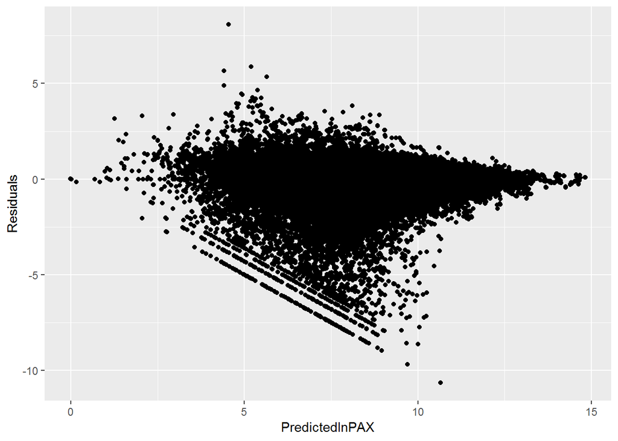

```r
w <- data.frame(x = log(PPML$fitted.values),
                y = log(market$passengers) - log(PPML$fitted.values))
names(w) <- c("PredictedlnPAX", "Residuals")

ggplot(data=w,aes(x = PredictedlnPAX, y = Residuals)) +
  geom_point()
```

It is a residual plot of ppml estimator. Both residuals and predicted values are in log scale. It appears that residuals are biased and they exhibit heteroscedasticity.

### Kernel

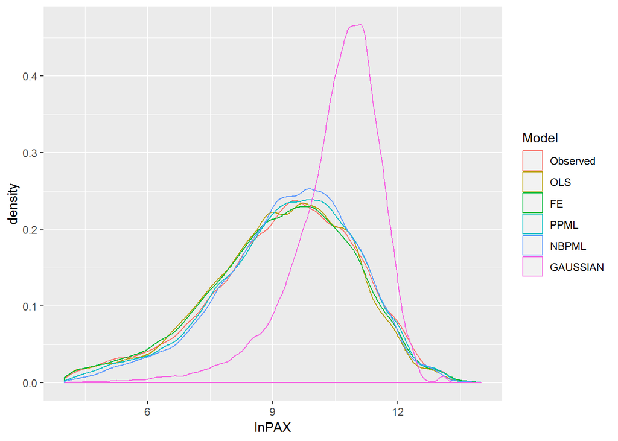

```r
q = data.frame(market$passengers, exp(OLS$fitted.values),
               exp(FE$fitted.values), PPML$fitted.values,
               NBPML$fitted.values, GAUSSIAN$fitted.values)
names(q) <- c("Observed","OLS", "FE", "PPML", "NBPML", "GAUSSIAN")
q.m <- melt(log(q))
names(q.m) <- c("Model", "lnPAX")
ggplot(q.m) +
  geom_density(aes(x = lnPAX, colour = Model)) +
  xlim(4,14)
```

To have an understanding of bias, variance, skewness and kurtosis of distributions of the predicted values of estimators, the graphs of the univariate kernel density estimations are examined here. It is hard to see the difference in the distributions of estimators visually (except for GAUSSIAN whose distribution is totally different) but we can make a table with moments of each distribution to compare their shape more precisely.

### Moments

#### D’Agostino skewness test (sampled 46340 because that is max sample size the test allows)

```r
agostino.test(sample(log(market$passengers), 46340))
```

```
##
##  D'Agostino skewness test
##
## data:  sample(log(market$passengers), 46340)
## skew = -0.97504, z = -72.65000, p-value < 2.2e-16
## alternative hypothesis: data have a skewness
```

We reject the null hypothesis which means the data has skewness.

#### Anscombe-Glynn test of kurtosis

```r
anscombe.test(log(market$passengers))
```

```
##
##  Anscombe-Glynn kurtosis test
##
## data:  log(market$passengers)
## kurt = 4.7427, z = 66.1950, p-value < 2.2e-16
## alternative hypothesis: kurtosis is not equal to 3
```

We reject the null hypothesis which means the data has kurtosis.

#### Jarque-Bera test for normality

```r
jarque.test(log(market$passengers))
```

```
##
##  Jarque-Bera Normality Test
##
## data:  log(market$passengers)
## JB = 31272, p-value < 2.2e-16
## alternative hypothesis: greater
```

We reject the null hypothesis which means that the data does not come from a normal distribution.

#### Moments of each distribution

```r
# fitted values of each estimator in log scale
fitted_values <- data.frame(log(market$passengers),
                            OLS$fitted.values,
                            FE$fitted.values,
                            log(PPML$fitted.values),
                            log(NBPML$fitted.values),
                            log(GAUSSIAN$fitted.values))

# names of estimators
names(fitted_values) <- c("Observed", "OLS", "FE", "PPML", "NBPML", "GAUSSIAN")

# Moments
Mean <- map(fitted_values, mean) %>% as.numeric()
Var <- map(fitted_values, var) %>% as.numeric()
Skewness <- map(fitted_values, skewness) %>% as.numeric()
Kurtosis <- map(fitted_values, kurtosis) %>% as.numeric()

# Put everything together
moments <- data.frame(Mean, Var, Skewness, Kurtosis,
                      row.names = c("Observed", "OLS", "FE", "PPML", "NBPML", "GAUSSIAN"))

moments
```

```
##              Mean      Var   Skewness Kurtosis
## Observed 9.144263 4.066700 -0.9645608 4.742721
## OLS      9.144263 3.175319 -0.5427250 3.280022
## FE       9.144263 3.389058 -0.5497361 3.362215
## PPML     9.330965 3.011074 -0.5440748 3.434798
## NBPML    9.384416 2.705961 -0.5187602 3.412289
## GAUSSIAN      NaN       NA        NaN      NaN
```

I do not know why we got NaN for GAUSSIAN.

### Predicted vs Observed plot

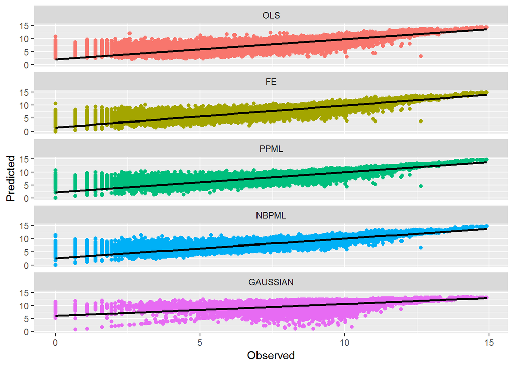

```r
r = data.frame(market$passengers, exp(OLS$fitted.values),
               exp(FE$fitted.values), PPML$fitted.values,
               NBPML$fitted.values, GAUSSIAN$fitted.values)
names(r) <- c("Observed","OLS", "FE", "PPML", "NBPML", "GAUSSIAN")
r.m <- log(r) %>% melt(id.vars = "Observed", measure.vars = c("OLS", "FE", "PPML",
                                                              "NBPML", "GAUSSIAN"))
names(r.m) <- c("Observed", "Model", "Predicted")
ggplot(r.m, aes(Observed, Predicted, colour = factor(Model))) +
  geom_point() +
  geom_smooth(method=lm, se=FALSE, color="black") +
  facet_wrap(~ Model, ncol = 1, scales = "fixed") +
  guides(colour = "none") +
  theme()
```

### Spot Analysis

```r
new.df <- market %>% filter(origin == "Atlanta")
predicted <- predict(PPML, new.df)
example <- cbind(new.df[,c("year", "destination", "passengers")], predicted, new.df[,c("capacity")])
names(example) <- c("Year", "Destination", "Observed", "Predicted", "Capacity")
example <- example %>% arrange(Year, Destination)
example$Predicted <- example$Predicted %>% as.integer()
head(example, 30)
```

```
##    Year  Destination Observed Predicted Capacity
## 1  2002        Aruba    47143     39060    67660
## 2  2002      Bermuda    60319     32067    79623
## 3  2002    Cape Town    63263     43170    81545
## 4  2002     Freeport    29203     16389    37988
## 5  2002 Johannesburg    26542     28091    44416
## 6  2002  Montego Bay   107569     99883   162490
## 7  2002       Nassau   104108     52473   149532
## 8  2002       Nassau   104108     52437   149532
## 9  2002 Saint Thomas    72389     35556    96714
## 10 2002          Sal      781       344      694
## 11 2003        Aruba    58283     54759    79401
## 12 2003      Bermuda    54596     42243    85841
## 13 2003    Cape Town    35777     21891    34006
## 14 2003     Freeport    36077     29109    50372
```

[output cut: 16 more lines]